# Course Project

Bruce Hadden  
14/11/2015

## Overview

This is the course project for the [Statistical Inference](https://class.coursera.org/statinference-034/) course. I investigate the exponential distribution in and compare it with the Central Limit Theorem, but taking a large sample of random exponentials and comparing with large sample of means of exponentials.

## Simulations

The random exponential values are simulated using the rexp function with the rate (lambda) set to 0.2.

I’ve generated two sets of simulation data:

1. Generated a sample of 1000 exponentials (population).
2. Generated 1000 samples of 40 exponentials (sample).

```r
lambda <- 0.2
n <- 40
no_sims <- 1000
sample <- matrix(rexp(n * no_sims, lambda), nrow=no_sims, ncol=n)
population <- rexp(1000, lambda) # a large sample of exponentials for comparison
sample_distribution <- (apply(sample, 1, mean))
```

## 1. Comparison of means

Here I compare 1. the mean of the exponentials with 2. the mean of the samples and 3. the theoretical mean of the exponential distribution. The theoretical mean of an exponential distribution is 1/lambda.

```r
theoretical_mean <- 1/lambda
mean_of_sample_distribution <- mean(sample_distribution)
mean_of_population <- mean(population)
```

Mean of Exponentials: 4.9279039  
Mean of Samples: 5.0359377  
Theoretical Mean: 5

## 2. Comparison of Variance

Here I compare the variance of random exponentials with the theoretical variance (1/λ<sup>2</sup>).

Then I compare the variance of the sample of random exponentials and the theoretical variance of samples (σ<sup>2</sup>/n).

```r
var_of_population <- var(population)
theoretical_variance <- 1/lambda**2
var_of_sample <- var(sample_distribution)
theoretical_var_of_sample <- theoretical_variance**2/no_sims
```

Variance of Exponentials: 22.5818095  
Theoretical Variance: 25

Variance of Samples: 0.6445113  
Theoretical Variance of Samples: 0.625

# 3. Sample Distribution

We see that the sample of means have a more normal distribution. Compared to the distribution of exponentials.

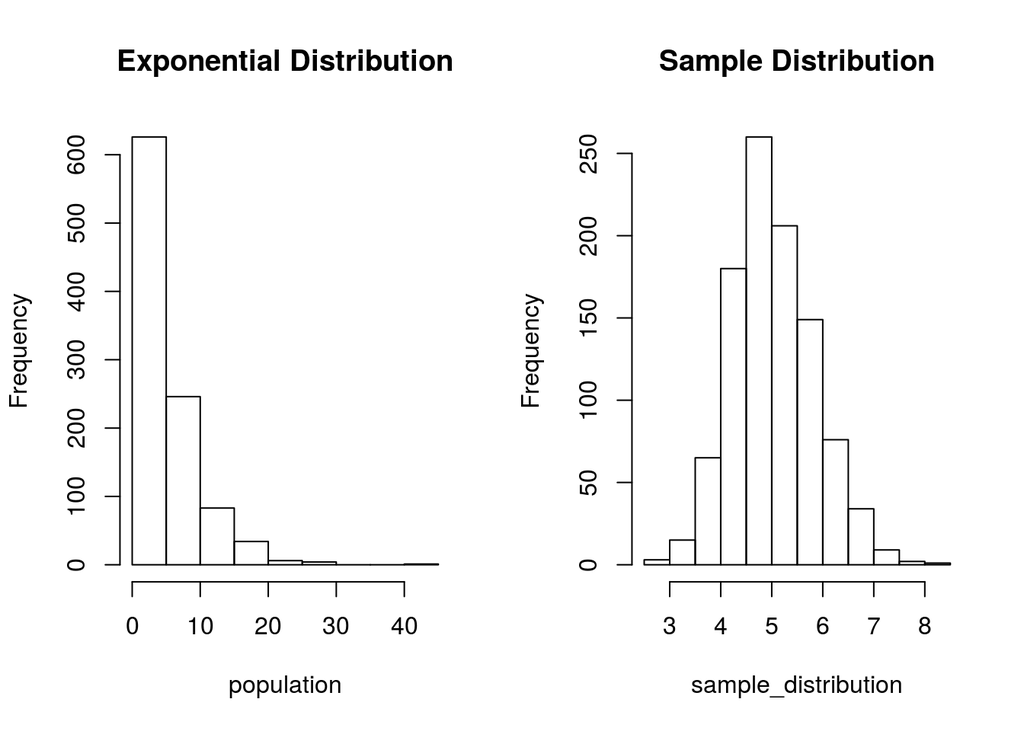

```r
par(mfrow=c(1,2))
hist(population, main = "Exponential Distribution")
hist(sample_distribution, main = "Sample Distribution")
```